# Developing Data Products_project

1/13/2022

## My app

In this project, I will create a Shiny application that assists you to choose your perfect diamonds. I use the `diamonds’ dataset in R as the primary sources for analysis. The dataset contains the prices and other attributes of almost 54,000 diamonds and thus, should be informative.

## Data Used for analysis

There are 53,940 samples and 10 characteristics of the diamonds.  
Let’s preview the data as below. In addition to the weight (carat) and size(x, y, z) that might affect the price of the diamond, the quality of cut, color, clarity are also determinants of the price of the diamond.

```
##      carat               cut        color        clarity          depth
##  Min.   :0.2000   Fair     : 1610   D: 6775   SI1    :13065   Min.   :43.00
##  1st Qu.:0.4000   Good     : 4906   E: 9797   VS2    :12258   1st Qu.:61.00
##  Median :0.7000   Very Good:12082   F: 9542   SI2    : 9194   Median :61.80
##  Mean   :0.7979   Premium  :13791   G:11292   VS1    : 8171   Mean   :61.75
##  3rd Qu.:1.0400   Ideal    :21551   H: 8304   VVS2   : 5066   3rd Qu.:62.50
##  Max.   :5.0100                     I: 5422   VVS1   : 3655   Max.   :79.00
##                                     J: 2808   (Other): 2531
##      table           price             x                y
##  Min.   :43.00   Min.   :  326   Min.   : 0.000   Min.   : 0.000
##  1st Qu.:56.00   1st Qu.:  950   1st Qu.: 4.710   1st Qu.: 4.720
##  Median :57.00   Median : 2401   Median : 5.700   Median : 5.710
##  Mean   :57.46   Mean   : 3933   Mean   : 5.731   Mean   : 5.735
##  3rd Qu.:59.00   3rd Qu.: 5324   3rd Qu.: 6.540   3rd Qu.: 6.540
##  Max.   :95.00   Max.   :18823   Max.   :10.740   Max.   :58.900
##
##        z
##  Min.   : 0.000
##  1st Qu.: 2.910
##  Median : 3.530
##  Mean   : 3.539
##  3rd Qu.: 4.040
##  Max.   :31.800
##
```

## A general picture of the price by carat

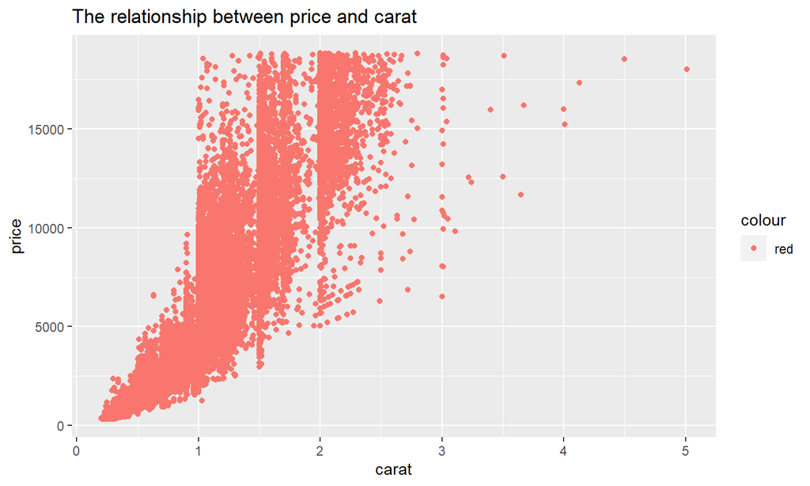

## If you are looking for a diamond with the carat less than 0.5

### The relationship between price and quality of the cut

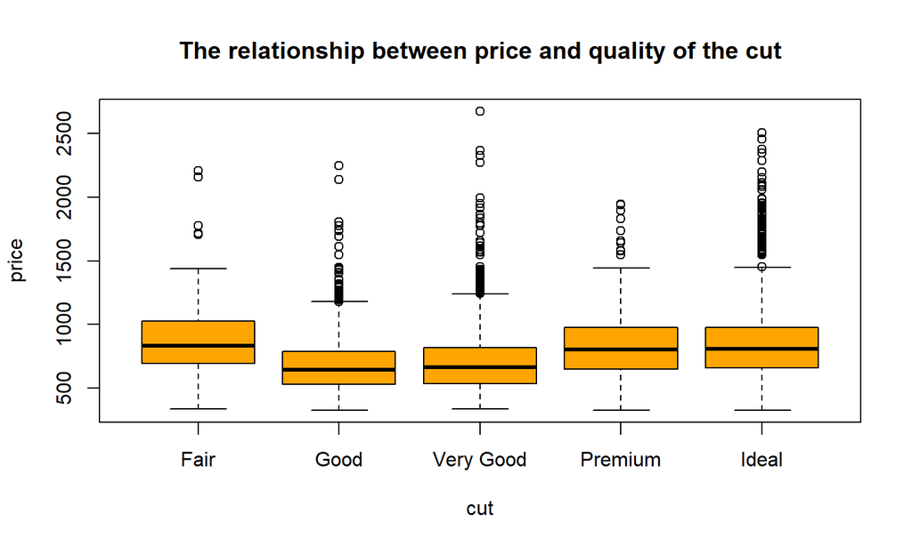

[output not shown]

## If you are looking for a diamond with the carat less than 0.5

### The relationship between price and clarity

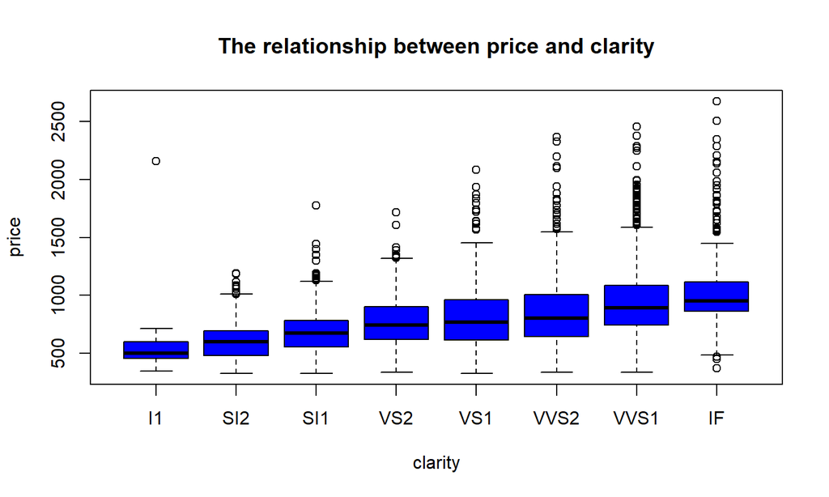

[output not shown]

## If you are looking for a diamond with the carat between 0.5 and 1

### The relationship between price and quality of the cut

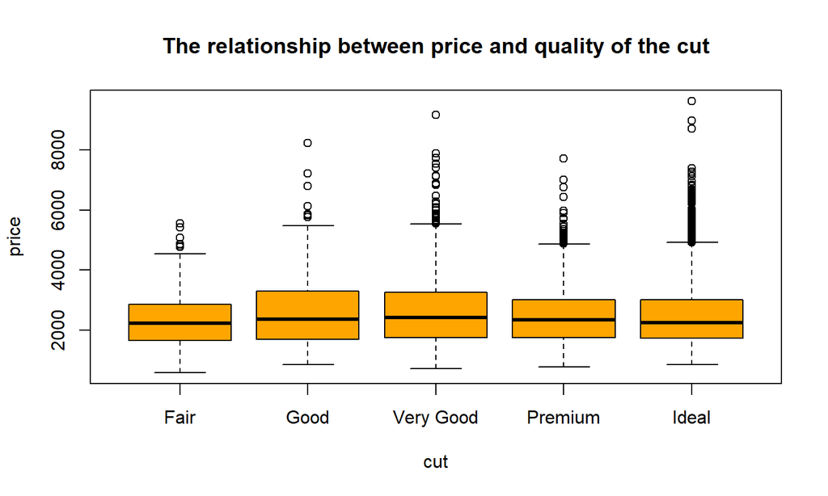

[output not shown]

## If you are looking for a diamond with the carat between 0.5 and 1

### The relationship between price and clarity

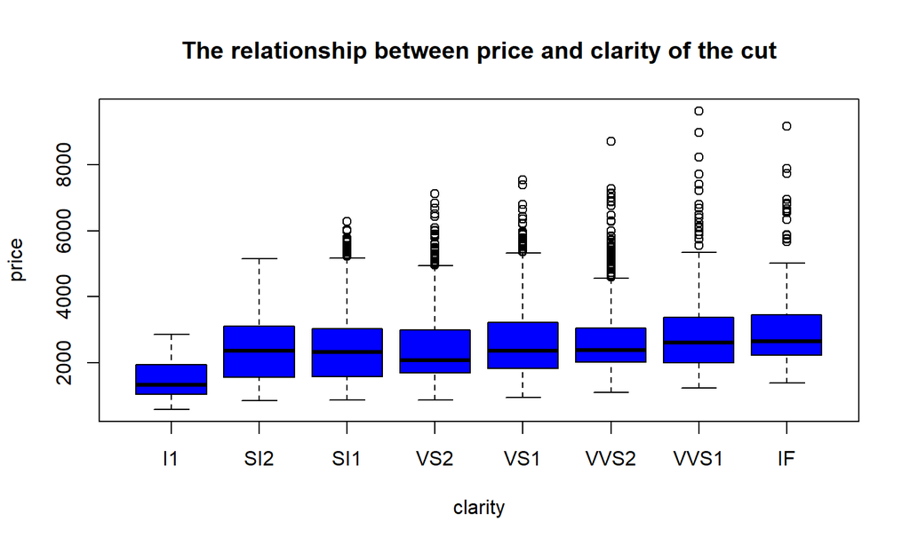

[output not shown]

## If you are looking for a diamond with the carat between 1 and 1.5

### The relationship between price and quality of the cut

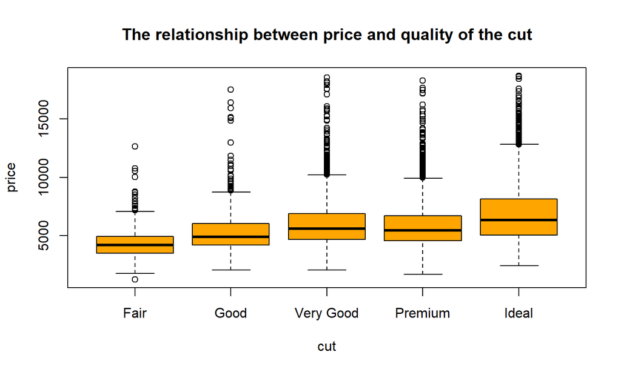

[output not shown]

[output cut: 63 more lines]

## If you are looking for a diamond with the carat between 1 and 1.5

### The relationship between price and clarity

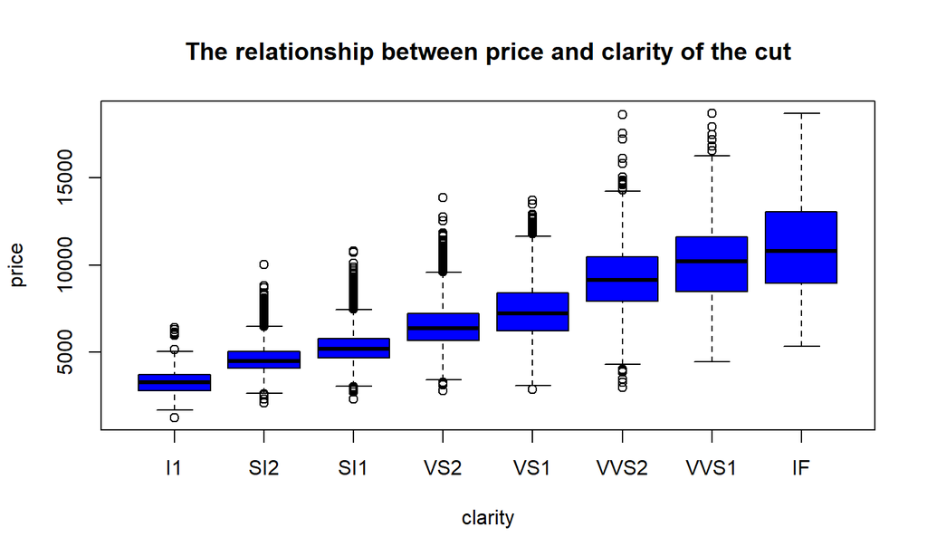

[output not shown]

[output cut: 61 more lines]

## Let’s apply the app to look for your perfect diamond

- The app developed for the the assignment is avalilable at: (https://weimf.shinyapps.io/myapp/)
- Files for developing the app and the presentation are avalilable on the GitHub: (https://github.com/weimf1990/Developing-Data-Products_project)